# 📚 Análise Comparativa de Candidaturas por Escolaridade no Estado de SP

### Projeto de TCC - Estado de São Paulo

Este notebook realiza a análise comparativa da distribuição, evolução temporal e impacto do **grau de instrução / escolaridade** dos candidatos nas eleições municipais no Estado de São Paulo, utilizando a base de microdados abertos do Tribunal Superior Eleitoral (TSE).

### 🎯 Objetivos Principais:

1. **Evolução do Perfil Educacional**: Quantificar e acompanhar a evolução absoluta e percentual dos graus de instrução dos candidatos ao longo dos pleitos municipais (2012, 2016, 2020 e 2024).
2. **Transição e Qualificação**: Avaliar a transição no perfil dos concorrentes, destacando o crescimento do **Ensino Superior Completo** e a retração proporcional de faixas com menor escolaridade formal.
3. **Recorte por Cargo (Executivo vs. Legislativo)**: Contrastar os níveis de instrução exigidos na prática eleitoral para os cargos de *Prefeito*, *Vice-Prefeito* e *Vereador*.
4. **Taxa de Sucesso / Eleitos**: Analisar a taxa de sucesso nas urnas de acordo com a escolaridade (proporção de candidatos com cada grau versus proporção de eleitos).
5. **Cruzamento Interseccional (Mulheres Eleitas vs. Homens Eleitos com Curso Superior)**: Comparar o perfil educacional entre os gêneros, com foco especial na proporção de mulheres eleitas com curso superior em relação aos homens eleitos com curso superior.

```python
# 1. Importação de bibliotecas e configuração do ambiente
import sys
from pathlib import Path
import pandas as pd
import matplotlib.pyplot as plt
import seaborn as sns

# Garantir acesso ao módulo src
BASE_DIR = Path.cwd().parent if Path.cwd().name == "notebooks" else Path.cwd()
if str(BASE_DIR) not in sys.path:
    sys.path.append(str(BASE_DIR))

try:
    from src.config import YEARS, RAW_DIR, TARGET_UF
except ImportError:
    YEARS = [2012, 2016, 2020, 2024]
    RAW_DIR = BASE_DIR / "data" / "raw"
    TARGET_UF = "SP"

# Configuração estética padronizada
sns.set_theme(style="whitegrid", font_scale=1.05)
plt.rcParams["figure.figsize"] = (12, 6)
plt.rcParams["figure.dpi"] = 120

# Ordem hierárquica oficial e padronizada de graus de instrução
ORDEM_ESCOLARIDADE = [
    "ANALFABETO",
    "LÊ E ESCREVE",
    "ENSINO FUNDAMENTAL INCOMPLETO",
    "ENSINO FUNDAMENTAL COMPLETO",
    "ENSINO MÉDIO INCOMPLETO",
    "ENSINO MÉDIO COMPLETO",
    "SUPERIOR INCOMPLETO",
    "SUPERIOR COMPLETO",
]

# Dicionário de padronização de grafias históricas do TSE
PADRAO_ESCOLARIDADE = {
    "ANALFABETO": "ANALFABETO",
    "LÊ E ESCREVE": "LÊ E ESCREVE",
    "LE E ESCREVE": "LÊ E ESCREVE",
    "FUNDAMENTAL INCOMPLETO": "ENSINO FUNDAMENTAL INCOMPLETO",
    "ENSINO FUNDAMENTAL INCOMPLETO": "ENSINO FUNDAMENTAL INCOMPLETO",
    "FUNDAMENTAL COMPLETO": "ENSINO FUNDAMENTAL COMPLETO",
    "ENSINO FUNDAMENTAL COMPLETO": "ENSINO FUNDAMENTAL COMPLETO",
    "MÉDIO INCOMPLETO": "ENSINO MÉDIO INCOMPLETO",
    "MEDIO INCOMPLETO": "ENSINO MÉDIO INCOMPLETO",
    "ENSINO MÉDIO INCOMPLETO": "ENSINO MÉDIO INCOMPLETO",
    "ENSINO MEDIO INCOMPLETO": "ENSINO MÉDIO INCOMPLETO",
    "MÉDIO COMPLETO": "ENSINO MÉDIO COMPLETO",
    "MEDIO COMPLETO": "ENSINO MÉDIO COMPLETO",
    "ENSINO MÉDIO COMPLETO": "ENSINO MÉDIO COMPLETO",
    "ENSINO MEDIO COMPLETO": "ENSINO MÉDIO COMPLETO",
    "SUPERIOR INCOMPLETO": "SUPERIOR INCOMPLETO",
    "SUPERIOR COMPLETO": "SUPERIOR COMPLETO",
}

# Paleta harmoniosa para graus de instrução
PALETTE_ESCOLARIDADE = dict(
    zip(
        ORDEM_ESCOLARIDADE,
        sns.color_palette("Spectral_r", len(ORDEM_ESCOLARIDADE))
    )
)

print(f"✓ Ambiente configurado! Anos analisados: {YEARS} (UF: {TARGET_UF})")
```

```
✓ Ambiente configurado! Anos analisados: [2012, 2016, 2020, 2024] (UF: SP)
```

## 📁 2. Carregamento e Consolidação dos Dados

Carregamos os dados de candidaturas para SP de todos os anos selecionados, filtrando as colunas essenciais para maximizar a performance.

```python
# Colunas essenciais para a análise de escolaridade
COLS = [
    "ANO_ELEICAO",
    "SG_UF",
    "NM_UE",
    "CD_CARGO",
    "DS_CARGO",
    "DS_GRAU_INSTRUCAO",
    "DS_GENERO",
    "DS_SIT_TOT_TURNO"
]

dfs = []
for ano in sorted(YEARS):
    csv_path = RAW_DIR / f"consulta_cand_{ano}" / f"consulta_cand_{ano}_{TARGET_UF}.csv"
    if not csv_path.exists():
        print(f"⚠️ Arquivo não encontrado: {csv_path.name} (Pulando...)")
        continue

    print(f"Lendo: {csv_path.name}...", end=" ", flush=True)
    df_ano = pd.read_csv(
        csv_path,
        sep=";",
        encoding="latin1",
        usecols=COLS,
        dtype={
            "ANO_ELEICAO": "int64",
            "SG_UF": "str",
            "NM_UE": "str",
            "DS_CARGO": "str",
            "DS_GRAU_INSTRUCAO": "str",
            "DS_GENERO": "str",
            "DS_SIT_TOT_TURNO": "str"
        },
        low_memory=False
    )

    # Padronizações textuais
    df_ano["DS_GRAU_INSTRUCAO"] = (
        df_ano["DS_GRAU_INSTRUCAO"]
        .fillna("NÃO INFORMADO")
        .str.upper()
        .str.strip()
        .map(lambda x: PADRAO_ESCOLARIDADE.get(x, x))
    )
    df_ano["DS_GENERO"] = df_ano["DS_GENERO"].fillna("NÃO INFORMADO").str.upper().str.strip()
    df_ano["DS_CARGO"] = df_ano["DS_CARGO"].fillna("").str.upper().str.strip()

    dfs.append(df_ano)
    print(f"({len(df_ano):,} registros)")

df_cand = pd.concat(dfs, ignore_index=True)

# Filtro para manter graus de instrução válidos mapeados
df_cand_val = df_cand[df_cand["DS_GRAU_INSTRUCAO"].isin(ORDEM_ESCOLARIDADE)].copy()
df_cand_val["DS_GRAU_INSTRUCAO"] = pd.Categorical(
    df_cand_val["DS_GRAU_INSTRUCAO"],
    categories=ORDEM_ESCOLARIDADE,
    ordered=True
)

print(f"\n✓ Total consolidado: {len(df_cand):,} registros (Válidos para escolaridade: {len(df_cand_val):,})")
df_cand_val.head()
```

```
Lendo: consulta_cand_2012_SP.csv... (81,739 registros)
Lendo: consulta_cand_2016_SP.csv... (86,781 registros)
Lendo: consulta_cand_2020_SP.csv... (93,988 registros)
Lendo: consulta_cand_2024_SP.csv... (78,422 registros)

✓ Total consolidado: 340,930 registros (Válidos para escolaridade: 340,794)
```

|  | ANO_ELEICAO | SG_UF | NM_UE | CD_CARGO | DS_CARGO | DS_GENERO | DS_GRAU_INSTRUCAO | DS_SIT_TOT_TURNO |
| --- | --- | --- | --- | --- | --- | --- | --- | --- |
| 0 | 2012 | SP | ITIRAPINA | 13 | VEREADOR | MASCULINO | ENSINO FUNDAMENTAL INCOMPLETO | SUPLENTE |
| 1 | 2012 | SP | CERQUEIRA CÉSAR | 13 | VEREADOR | MASCULINO | SUPERIOR COMPLETO | SUPLENTE |
| 2 | 2012 | SP | VALINHOS | 13 | VEREADOR | MASCULINO | SUPERIOR COMPLETO | SUPLENTE |
| 3 | 2012 | SP | MAUÁ | 13 | VEREADOR | MASCULINO | ENSINO MÉDIO COMPLETO | SUPLENTE |
| 4 | 2012 | SP | MAUÁ | 13 | VEREADOR | MASCULINO | ENSINO MÉDIO COMPLETO | NÃO ELEITO |

## 📈 3. Panorama Geral: Evolução do Grau de Instrução por Pleito

Abaixo geramos as tabelas de frequência absoluta e relativa (%) da distribuição educacional dos candidatos a cada pleito eleitoral.

```python
# Tabela de Frequência Absoluta
tab_abs_inst = pd.crosstab(
    df_cand_val["ANO_ELEICAO"],
    df_cand_val["DS_GRAU_INSTRUCAO"],
    margins=True,
    margins_name="Total"
)
print("--- Quantidade Absoluta de Candidatos por Grau de Instrução e Ano ---")
display(tab_abs_inst)

# Tabela de Frequência Relativa (%)
tab_pct_inst = pd.crosstab(
    df_cand_val["ANO_ELEICAO"],
    df_cand_val["DS_GRAU_INSTRUCAO"],
    normalize="index"
) * 100
print("\n--- Distribuição Percentual (%) da Escolaridade por Ano Eleitoral ---")
display(tab_pct_inst.round(2))
```

```
--- Quantidade Absoluta de Candidatos por Grau de Instrução e Ano ---
```

| DS_GRAU_INSTRUCAO ANO_ELEICAO | ANALFABETO | LÊ E ESCREVE | ENSINO FUNDAMENTAL INCOMPLETO | ENSINO FUNDAMENTAL COMPLETO | ENSINO MÉDIO INCOMPLETO | ENSINO MÉDIO COMPLETO | SUPERIOR INCOMPLETO | SUPERIOR COMPLETO | Total |
| --- | --- | --- | --- | --- | --- | --- | --- | --- | --- |
| 2012 | 4 | 1820 | 11482 | 12104 | 3513 | 29424 | 3618 | 19734 | 81699 |
| 2016 | 2 | 1765 | 10336 | 11959 | 3949 | 33297 | 3821 | 21630 | 86759 |
| 2020 | 1 | 2320 | 8179 | 11108 | 4145 | 36996 | 4638 | 26528 | 93915 |
| 2024 | 0 | 1425 | 5530 | 7958 | 3185 | 31025 | 3714 | 25584 | 78421 |
| Total | 7 | 7330 | 35527 | 43129 | 14792 | 130742 | 15791 | 93476 | 340794 |

```
--- Distribuição Percentual (%) da Escolaridade por Ano Eleitoral ---
```

| DS_GRAU_INSTRUCAO ANO_ELEICAO | ANALFABETO | LÊ E ESCREVE | ENSINO FUNDAMENTAL INCOMPLETO | ENSINO FUNDAMENTAL COMPLETO | ENSINO MÉDIO INCOMPLETO | ENSINO MÉDIO COMPLETO | SUPERIOR INCOMPLETO | SUPERIOR COMPLETO |
| --- | --- | --- | --- | --- | --- | --- | --- | --- |
| 2012 | 0.0 | 2.23 | 14.05 | 14.82 | 4.30 | 36.02 | 4.43 | 24.15 |
| 2016 | 0.0 | 2.03 | 11.91 | 13.78 | 4.55 | 38.38 | 4.40 | 24.93 |
| 2020 | 0.0 | 2.47 | 8.71 | 11.83 | 4.41 | 39.39 | 4.94 | 28.25 |
| 2024 | 0.0 | 1.82 | 7.05 | 10.15 | 4.06 | 39.56 | 4.74 | 32.62 |

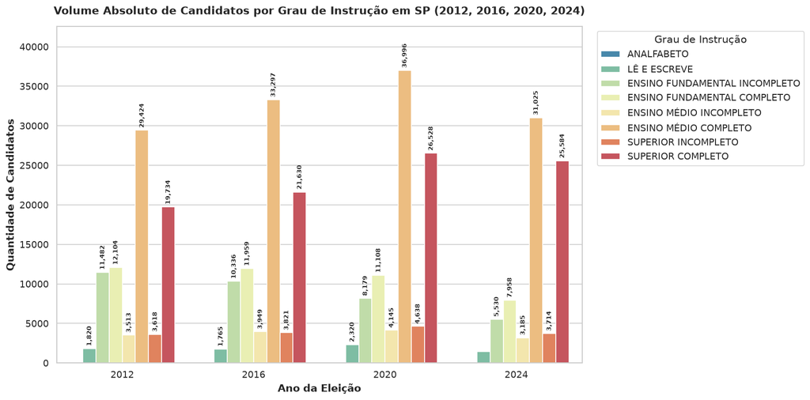

```python
# Gráfico de Barras da Evolução da Escolaridade
df_plot_inst = df_cand_val.groupby(["ANO_ELEICAO", "DS_GRAU_INSTRUCAO"], observed=True).size().reset_index(name="QTD")

plt.figure(figsize=(14, 7))
ax = sns.barplot(
    data=df_plot_inst,
    x="ANO_ELEICAO",
    y="QTD",
    hue="DS_GRAU_INSTRUCAO",
    palette=PALETTE_ESCOLARIDADE
)

for p in ax.patches:
    height = p.get_height()
    if height > 1500:
        ax.annotate(
            f"{int(height):,}",
            (p.get_x() + p.get_width() / 2., height),
            ha='center', va='bottom',
            fontsize=8, fontweight='bold', xytext=(0, 3),
            textcoords='offset points', rotation=90
        )

anos_str = ", ".join(map(str, sorted(df_cand_val["ANO_ELEICAO"].unique())))
plt.title(f"Volume Absoluto de Candidatos por Grau de Instrução em {TARGET_UF} ({anos_str})", fontsize=13, fontweight='bold', pad=15)
plt.xlabel("Ano da Eleição", fontweight='bold')
plt.ylabel("Quantidade de Candidatos", fontweight='bold')
plt.ylim(0, df_plot_inst["QTD"].max() * 1.15)
plt.legend(title="Grau de Instrução", bbox_to_anchor=(1.02, 1), loc='upper left')
plt.tight_layout()
plt.show()
```

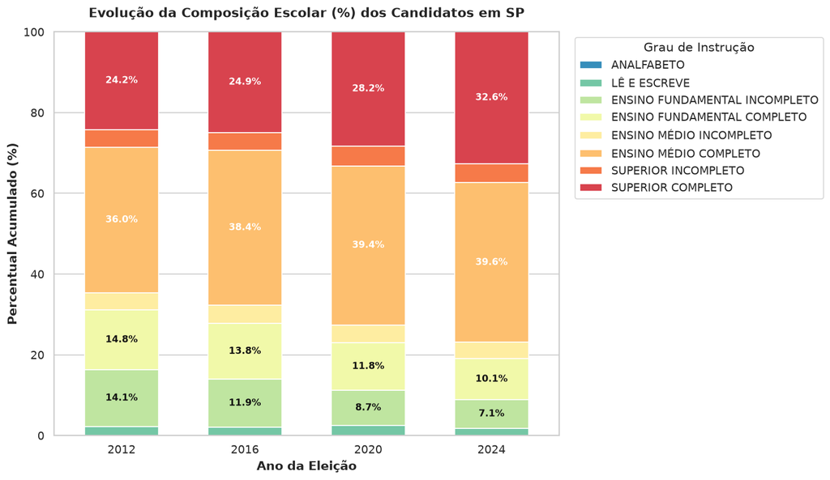

```python
# Gráfico de Barras Empilhadas 100% (Composição Percentual da Escolaridade)
fig, ax = plt.subplots(figsize=(12, 7))
tab_pct_inst.plot(
    kind="bar",
    stacked=True,
    color=[PALETTE_ESCOLARIDADE[c] for c in ORDEM_ESCOLARIDADE if c in tab_pct_inst.columns],
    ax=ax,
    width=0.6
)

# Adicionar rótulos nas fatias com percentuais representativos (>= 7%)
for i, (ano, row) in enumerate(tab_pct_inst.iterrows()):
    cum_height = 0
    for col in [c for c in ORDEM_ESCOLARIDADE if c in tab_pct_inst.columns]:
        val = row[col]
        if val >= 7.0:
            ax.text(
                i,
                cum_height + val / 2,
                f"{val:.1f}%",
                ha='center',
                va='center',
                color='white' if val > 15 else '#111111',
                fontweight='bold',
                fontsize=9.5
            )
        cum_height += val

plt.title(f"Evolução da Composição Escolar (%) dos Candidatos em {TARGET_UF}", fontsize=13, fontweight='bold', pad=15)
plt.xlabel("Ano da Eleição", fontweight='bold')
plt.ylabel("Percentual Acumulado (%)", fontweight='bold')
plt.ylim(0, 100)
plt.xticks(rotation=0)
plt.legend(title="Grau de Instrução", bbox_to_anchor=(1.02, 1), loc='upper left')
plt.tight_layout()
plt.show()
```

## 🏛️ 4. Recorte por Cargo: Executivo (*Prefeito* / *Vice-Prefeito*) vs. Legislativo (*Vereador*)

Como varia o perfil educacional de acordo com o cargo concorrido? Há maior concentração de ensino superior nos cargos executivos do que nas câmaras municipais?

```
--- Percentual (%) de Candidatos com Ensino Superior Completo por Cargo: ---
```

| ANO_ELEICAO DS_CARGO | 2012 | 2016 | 2020 | 2024 |
| --- | --- | --- | --- | --- |
| PREFEITO | 59.12 | 60.99 | 65.73 | 67.65 |
| VEREADOR | 22.50 | 23.18 | 26.29 | 30.92 |
| VICE-PREFEITO | 47.66 | 50.27 | 52.25 | 55.42 |

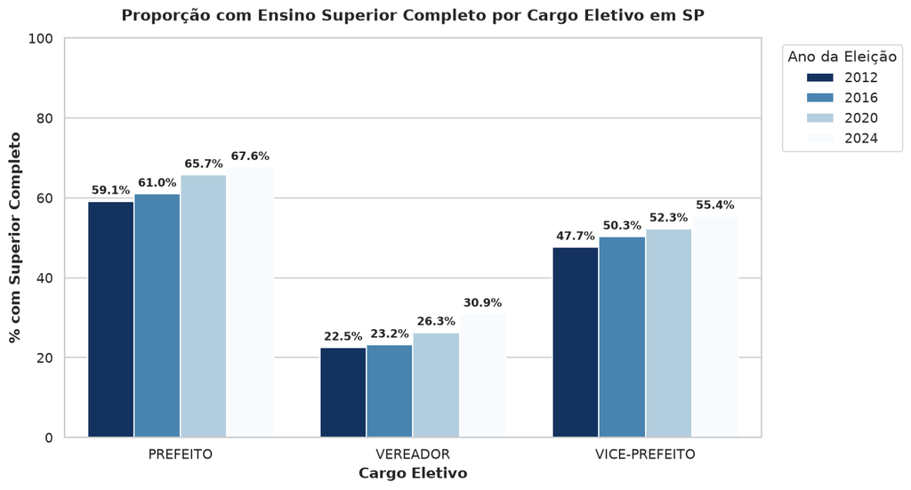

```python
# Percentual de Ensino Superior Completo por Cargo e Ano
cargos_foco = ["PREFEITO", "VICE-PREFEITO", "VEREADOR"]
df_cargos = df_cand_val[df_cand_val["DS_CARGO"].isin(cargos_foco)].copy()

pct_sup_cargo = (
    df_cargos[df_cargos["DS_GRAU_INSTRUCAO"] == "SUPERIOR COMPLETO"]
    .groupby(["DS_CARGO", "ANO_ELEICAO"]).size() /
    df_cargos.groupby(["DS_CARGO", "ANO_ELEICAO"]).size() * 100
).reset_index(name="PCT_SUPERIOR_COMPLETO")

print("--- Percentual (%) de Candidatos com Ensino Superior Completo por Cargo: ---")
tab_cargo_sup = pct_sup_cargo.pivot(index="DS_CARGO", columns="ANO_ELEICAO", values="PCT_SUPERIOR_COMPLETO")
display(tab_cargo_sup.round(2))

# Gráfico comparativo de Ensino Superior por cargo ao longo dos anos
plt.figure(figsize=(11, 6))
ax = sns.barplot(
    data=pct_sup_cargo,
    x="DS_CARGO",
    y="PCT_SUPERIOR_COMPLETO",
    hue="ANO_ELEICAO",
    palette="Blues_r"
)

for p in ax.patches:
    height = p.get_height()
    if height > 0:
        ax.annotate(
            f"{height:.1f}%",
            (p.get_x() + p.get_width() / 2., height),
            ha='center', va='bottom',
            fontsize=9.5, fontweight='bold', xytext=(0, 4),
            textcoords='offset points'
        )

plt.title(f"Proporção com Ensino Superior Completo por Cargo Eletivo em {TARGET_UF}", fontsize=13, fontweight='bold', pad=15)
plt.xlabel("Cargo Eletivo", fontweight='bold')
plt.ylabel("% com Superior Completo", fontweight='bold')
plt.ylim(0, 100)
plt.legend(title="Ano da Eleição", bbox_to_anchor=(1.02, 1), loc='upper left')
plt.tight_layout()
plt.show()
```

## 🏆 5. Taxa de Sucesso: Candidatos por Escolaridade vs. Candidatos Eleitos

Ter maior nível de instrução aumenta as chances efetivas de eleição? Analisamos o perfil dos candidatos no universo total versus o perfil entre os que foram eleitos.

```
--- Comparativo de Distribuição de Escolaridade nas Eleições de 2024 ---
```

| DS_GRAU_INSTRUCAO | % Total Candidatos | % Entre os Eleitos |
| --- | --- | --- |
| ANALFABETO | 0.00 | 0.00 |
| LÊ E ESCREVE | 1.82 | 0.76 |
| ENSINO FUNDAMENTAL INCOMPLETO | 7.05 | 4.30 |
| ENSINO FUNDAMENTAL COMPLETO | 10.15 | 6.99 |
| ENSINO MÉDIO INCOMPLETO | 4.06 | 2.57 |
| ENSINO MÉDIO COMPLETO | 39.56 | 34.24 |
| SUPERIOR INCOMPLETO | 4.74 | 3.99 |
| SUPERIOR COMPLETO | 32.62 | 47.16 |

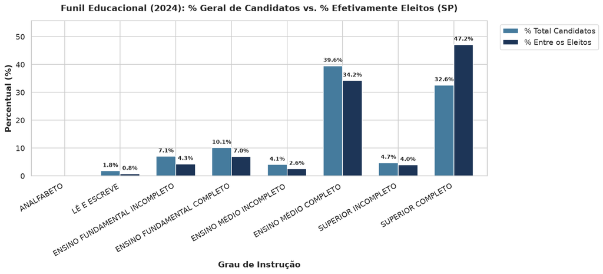

```python
# Identificação de candidatos eleitos (abrange nomenclaturas históricas do TSE)
STATUS_ELEITO = [
    "ELEITO",
    "ELEITO POR QP",
    "ELEITO POR MÉDIA",
    "ELEITO POR MDIA",
    "MÉDIA",
    "MEDIA"
]
df_cand_val["ST_ELEITO"] = df_cand_val["DS_SIT_TOT_TURNO"].fillna("").str.upper().str.strip().isin(STATUS_ELEITO)
df_eleitos_val = df_cand_val[df_cand_val["ST_ELEITO"]].copy()

# Comparação da distribuição de escolaridade no ano mais recente (2024)
ano_recente = sorted(df_cand_val["ANO_ELEICAO"].unique())[-1]

dist_cand = (
    df_cand_val[df_cand_val["ANO_ELEICAO"] == ano_recente]["DS_GRAU_INSTRUCAO"]
    .value_counts(normalize=True)[ORDEM_ESCOLARIDADE] * 100
)
dist_eleit = (
    df_eleitos_val[df_eleitos_val["ANO_ELEICAO"] == ano_recente]["DS_GRAU_INSTRUCAO"]
    .value_counts(normalize=True)[ORDEM_ESCOLARIDADE] * 100
)

df_comp_eleitos = pd.DataFrame({
    "% Total Candidatos": dist_cand,
    "% Entre os Eleitos": dist_eleit
})

print(f"--- Comparativo de Distribuição de Escolaridade nas Eleições de {ano_recente} ---")
display(df_comp_eleitos.round(2))

# Gráfico comparativo de distribuição
ax = df_comp_eleitos.plot(
    kind="bar",
    figsize=(13, 6),
    color=["#457b9d", "#1d3557"],
    width=0.7
)

for p in ax.patches:
    height = p.get_height()
    if height > 0:
        ax.annotate(
            f"{height:.1f}%",
            (p.get_x() + p.get_width() / 2., height),
            ha='center', va='bottom',
            fontsize=8.5, fontweight='bold', xytext=(0, 4),
            textcoords='offset points'
        )

plt.title(f"Funil Educacional ({ano_recente}): % Geral de Candidatos vs. % Efetivamente Eleitos ({TARGET_UF})", fontsize=13, fontweight='bold', pad=15)
plt.xlabel("Grau de Instrução", fontweight='bold')
plt.ylabel("Percentual (%)", fontweight='bold')
plt.ylim(0, max(50, df_comp_eleitos.max().max() * 1.18))
plt.xticks(rotation=30, ha="right")
plt.legend(bbox_to_anchor=(1.02, 1), loc='upper left')
plt.tight_layout()
plt.show()
```

## 👥 6. Cruzamento Interseccional: Escolaridade por Gênero

Como a escolaridade varia entre homens e mulheres candidatas e, fundamentalmente, **entre homens e mulheres que foram efetivamente eleitos(as)**?

Abaixo analisamos:

1. **Candidatas vs. Candidatos**: Proporção com Ensino Superior Completo no momento da candidatura.
2. **Mulheres Eleitas vs. Homens Eleitos**: Proporção de pessoas diplomadas com Ensino Superior entre quem conquistou o mandato.

```
--- Percentual (%) de Ensino Superior Completo entre Candidatos por Gênero e Ano: ---
```

| DS_GENERO ANO_ELEICAO | FEMININO | MASCULINO |
| --- | --- | --- |
| 2012 | 26.14 | 23.23 |
| 2016 | 26.63 | 24.13 |
| 2020 | 31.26 | 26.72 |
| 2024 | 36.74 | 30.49 |

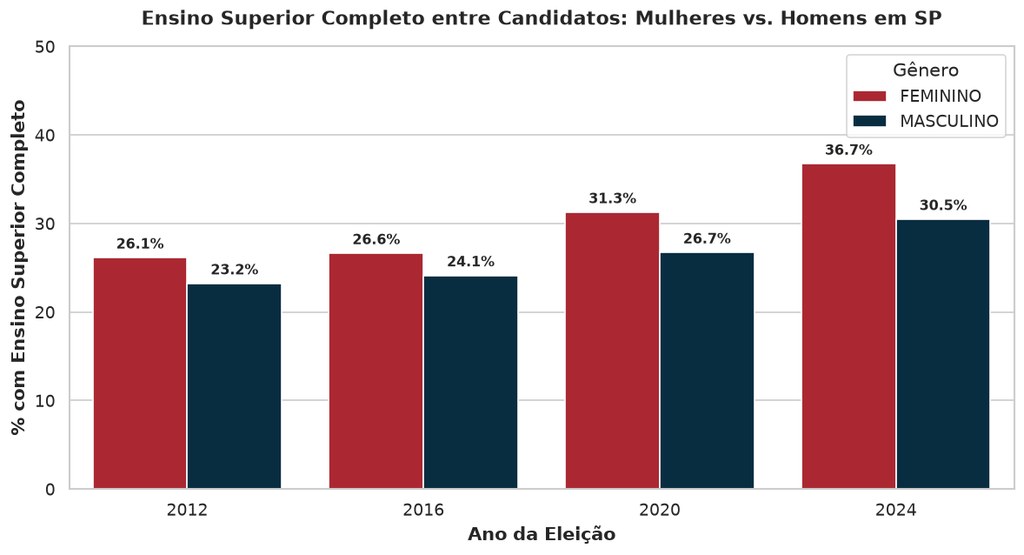

```python
# 6.1 Proporção de Ensino Superior Completo no Universo Geral de Candidatos por Gênero
df_genero_val = df_cand_val[df_cand_val["DS_GENERO"].isin(["FEMININO", "MASCULINO"])].copy()

prop_sup_cand = (
    df_genero_val[df_genero_val["DS_GRAU_INSTRUCAO"] == "SUPERIOR COMPLETO"]
    .groupby(["ANO_ELEICAO", "DS_GENERO"]).size() /
    df_genero_val.groupby(["ANO_ELEICAO", "DS_GENERO"]).size() * 100
).reset_index(name="PCT_SUPERIOR_CAND")

print("--- Percentual (%) de Ensino Superior Completo entre Candidatos por Gênero e Ano: ---")
tab_sup_cand_pivot = prop_sup_cand.pivot(index="ANO_ELEICAO", columns="DS_GENERO", values="PCT_SUPERIOR_CAND")
display(tab_sup_cand_pivot.round(2))

# Gráfico: Mulheres Candidatas vs. Homens Candidatos
plt.figure(figsize=(10, 5.5))
ax = sns.barplot(
    data=prop_sup_cand,
    x="ANO_ELEICAO",
    y="PCT_SUPERIOR_CAND",
    hue="DS_GENERO",
    palette={"FEMININO": "#c1121f", "MASCULINO": "#003049"}
)

for p in ax.patches:
    height = p.get_height()
    if height > 0:
        ax.annotate(
            f"{height:.1f}%",
            (p.get_x() + p.get_width() / 2., height),
            ha='center', va='bottom',
            fontsize=9.5, fontweight='bold', xytext=(0, 4),
            textcoords='offset points'
        )

plt.title(f"Ensino Superior Completo entre Candidatos: Mulheres vs. Homens em {TARGET_UF}", fontsize=13, fontweight='bold', pad=15)
plt.xlabel("Ano da Eleição", fontweight='bold')
plt.ylabel("% com Ensino Superior Completo", fontweight='bold')
plt.ylim(0, max(50, prop_sup_cand["PCT_SUPERIOR_CAND"].max() * 1.2))
plt.legend(title="Gênero")
plt.tight_layout()
plt.show()
```

### 🎓 6.2 Mulheres Eleitas com Ensino Superior vs. Homens Eleitos com Ensino Superior

Abaixo comparamos diretamente o perfil educacional das **mulheres que venceram as eleições** versus os **homens que venceram as eleições**.

```
--- Comparativo Completo: % com Ensino Superior Completo por Gênero (Candidatos vs. Eleitos) ---
```

| ANO_ELEICAO | % Mulheres Candidatas (Superior) | % Mulheres Eleitas (Superior) | % Homens Candidatos (Superior) | % Homens Eleitos (Superior) |
| --- | --- | --- | --- | --- |
| 2012 | 26.14 | 53.20 | 23.23 | 35.08 |
| 2016 | 26.63 | 54.09 | 24.13 | 37.15 |
| 2020 | 31.26 | 59.18 | 26.72 | 38.92 |
| 2024 | 36.74 | 61.78 | 30.49 | 44.19 |

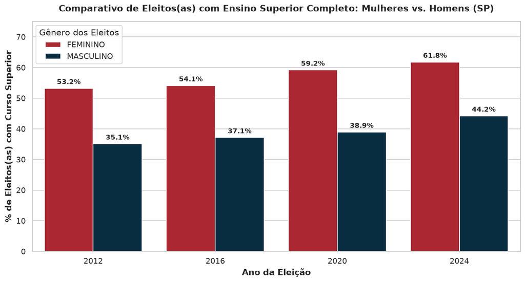

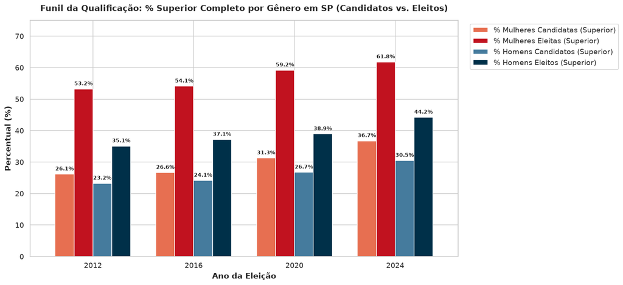

```python
# 6.2 Comparação direta: % com Ensino Superior Completo entre Mulheres Eleitas vs. Homens Eleitos
df_eleitos_genero = df_genero_val[df_genero_val["ST_ELEITO"]].copy()

# Percentual de Superior Completo entre os Eleitos por Gênero
prop_sup_eleitos = (
    df_eleitos_genero[df_eleitos_genero["DS_GRAU_INSTRUCAO"] == "SUPERIOR COMPLETO"]
    .groupby(["ANO_ELEICAO", "DS_GENERO"]).size() /
    df_eleitos_genero.groupby(["ANO_ELEICAO", "DS_GENERO"]).size() * 100
).reset_index(name="PCT_SUPERIOR_ELEITOS")

# Tabela consolidada comparativa: Candidatos vs. Eleitos por Gênero
tab_comparativo_genero_sup = pd.DataFrame({
    "% Mulheres Candidatas (Superior)": prop_sup_cand[prop_sup_cand["DS_GENERO"] == "FEMININO"].set_index("ANO_ELEICAO")["PCT_SUPERIOR_CAND"],
    "% Mulheres Eleitas (Superior)": prop_sup_eleitos[prop_sup_eleitos["DS_GENERO"] == "FEMININO"].set_index("ANO_ELEICAO")["PCT_SUPERIOR_ELEITOS"],
    "% Homens Candidatos (Superior)": prop_sup_cand[prop_sup_cand["DS_GENERO"] == "MASCULINO"].set_index("ANO_ELEICAO")["PCT_SUPERIOR_CAND"],
    "% Homens Eleitos (Superior)": prop_sup_eleitos[prop_sup_eleitos["DS_GENERO"] == "MASCULINO"].set_index("ANO_ELEICAO")["PCT_SUPERIOR_ELEITOS"],
})

print("--- Comparativo Completo: % com Ensino Superior Completo por Gênero (Candidatos vs. Eleitos) ---")
display(tab_comparativo_genero_sup.round(2))

# Gráfico 1: Comparativo Direto de Mulheres Eleitas vs. Homens Eleitos com Curso Superior
plt.figure(figsize=(11, 6))
ax = sns.barplot(
    data=prop_sup_eleitos,
    x="ANO_ELEICAO",
    y="PCT_SUPERIOR_ELEITOS",
    hue="DS_GENERO",
    palette={"FEMININO": "#c1121f", "MASCULINO": "#003049"}
)

for p in ax.patches:
    height = p.get_height()
    if height > 0:
        ax.annotate(
            f"{height:.1f}%",
            (p.get_x() + p.get_width() / 2., height),
            ha='center', va='bottom',
            fontsize=10, fontweight='bold', xytext=(0, 4),
            textcoords='offset points'
        )

plt.title(f"Comparativo de Eleitos(as) com Ensino Superior Completo: Mulheres vs. Homens ({TARGET_UF})", fontsize=13, fontweight='bold', pad=15)
plt.xlabel("Ano da Eleição", fontweight='bold')
plt.ylabel("% de Eleitos(as) com Curso Superior", fontweight='bold')
plt.ylim(0, max(75, prop_sup_eleitos["PCT_SUPERIOR_ELEITOS"].max() * 1.18))
plt.legend(title="Gênero dos Eleitos", loc="upper left")
plt.tight_layout()
plt.show()

# Gráfico 2: Comparativo 4 Vias (Candidatas vs Eleitas vs Candidatos vs Eleitos)
ax = tab_comparativo_genero_sup.plot(
    kind="bar",
    figsize=(14, 6.5),
    color=["#e76f51", "#c1121f", "#457b9d", "#003049"],
    width=0.75
)

for p in ax.patches:
    height = p.get_height()
    if height > 0:
        ax.annotate(
            f"{height:.1f}%",
            (p.get_x() + p.get_width() / 2., height),
            ha='center', va='bottom',
            fontsize=8.5, fontweight='bold', xytext=(0, 4),
            textcoords='offset points'
        )

plt.title(f"Funil da Qualificação: % Superior Completo por Gênero em {TARGET_UF} (Candidatos vs. Eleitos)", fontsize=13, fontweight='bold', pad=15)
plt.xlabel("Ano da Eleição", fontweight='bold')
plt.ylabel("Percentual (%)", fontweight='bold')
plt.ylim(0, max(75, tab_comparativo_genero_sup.max().max() * 1.18))
plt.xticks(rotation=0)
plt.legend(bbox_to_anchor=(1.02, 1), loc='upper left')
plt.tight_layout()
plt.show()
```